# Predicting Term Deposit Subscription Using Client and Campaign Data

## MATH2319 Assignment - Phase 2

### Project Group 28

#### Alfred Chan (s3990477)

#### Minh Phuc Le (s3916144)

#### Anh Le Thuy Nhat (s3927359)

- 1. Introduction
  - 1.1 Phase 1 Summary
  - 1.2 Report Overview
  - 1.3 Overview of Methodology
- 2. Predictive Modelling
  - 2.0 Data Preparation
  - 2.1 Feature Selection
  - 2.2 Model Fitting & Tuning
  - 2.2.0 Set Up
  - 2.2.1 Logistic Regression
  - 2.2.2 K-Nearest Neighbors
  - 2.2.3 Decision Tree
  - 2.2.4 Random Forest
  - 2.2.5 Support Vector Machine
  - 2.2.6 Neural Network Model Fitting & Tuning
  - 2.3 Model Comparison
- 3. Critique & Limitations
- 4. Summary & Conclusion
  - 4.1 Project Summary
  - 4.2 Summary Findings
  - 4.3 Conclusion
- 5. References

## 1. Introduction

### 1.1 Phase 1 Summary

In Phase 1 of our project, we explored the Bank Marketing Dataset from Kaggle, which contains client demographic, financial and marketing campaign data collected during Portuguese bank telemarketing campaigns. The dataset includes 11,162 records and 17 initial features, with the target variable being whether a client subscribed to a term deposit.

To streamline analysis and reduce computational load, we randomly sampled 5,000 records using a fixed seed for reproducibility. We conducted comprehensive data cleaning and preprocessing, starting with the removal of irrelevant or low-quality features (contact, day, pdays) that were either redundant, sparsely populated or had limited predictive value. We validated data types, confirmed there were no missing values, and ensured categorical values were consistently formatted. We also consolidated infrequent or ambiguous categories. For example, merging "other" into "failure" in the poutcome feature to improve interpretability.

We identified and retained outliers in variables like balance and previous, recognising that extreme financial values could reflect important customer behaviours. Our final cleaned dataset consisted of 15 predictor features and one binary target variable deposit.

In the Data Exploration & Visualisation section, we used univariate, bivariate and multivariate visualisations to explore feature distributions and relationships with the target variable. Key findings included:

- Higher subscription rates among clients with tertiary education, single marital status, and no housing or personal loans.
- A strong positive correlation between call duration and subscription likelihood.
- The outcome of previous campaigns and job type were also significant indicators of client responsiveness.

These insights inform our feature selection and modelling strategies in Phase 2. We aim to build robust classifiers by leveraging the most influential features identified in Phase 1 and evaluate multiple machine learning models to determine the best approach for predicting term deposit subscriptions.

### 1.2 Report Overview

This Phase 2 report presents a comprehensive approach to building and evaluating machine learning models for predicting whether a bank client will subscribe to a term deposit. Building on the data cleaning and exploratory analysis conducted in Phase 1, this report transitions into supervised learning and model optimisation to support more accurate targeting strategies for the bank’s marketing campaigns.

The report is organised into the following key sections:

#### Introduction:

Summarises the objectives of the project, reviews the work conducted in Phase 1, and introduces the modelling methodology used in Phase 2.

#### Data Preparation:

Begins by loading the cleaned dataset of 5,000 observations prepared in Phase 1. Categorical features are one-hot encoded, numerical features are standardised using StandardScaler, and the data is split into training and testing subsets using a 80:20 stratified split to preserve class balance.

#### Predictive Modelling:

This section consolidates all key modelling stages:

- Feature Selection is conducted using SelectKBest with ANOVA F-statistics (f_classif) to identify the ten most predictive features.
- Model Fitting & Hyperparameter Tuning is applied to five traditional classifiers: Logistic Regression, K-Nearest Neighbours, Decision Tree, Random Forest and Support Vector Machine. Each model is trained using pipelines with cross-validated grid search and evaluated using accuracy, recall, F1-score and plot.
- As part of the Advanced Submission, a Neural Network is developed using Keras/TensorFlow. We tune five key hyperparameters and provide narrative explanations supported by tuning plots.
- In the Model Comparison, all models are assessed using 5-fold cross-validation. Evaluation is based on accuracy and AUC to account for class imbalance. Paired t-tests are conducted to determine the statistical significance of performance differences.

#### Critique & Limitations:

Reflects on the strengths and weaknesses of the models, with particular attention to class imbalance, overfitting, and the trade-offs between model complexity and interpretability.

#### Summary & Conclusions:

Recaps the overall modelling process, highlights the top-performing models, and offers actionable recommendations for improving future campaign effectiveness through data-driven insights.

Overall, these sections provide a complete and rigorous account of our Phase 2 approach and results, building toward a robust solution for predicting term deposit subscriptions.

### 1.3 Overview of Methodology

Our Phase 2 modelling methodology follows a systematic machine learning pipeline designed to ensure rigorous evaluation, reliable performance and practical interpretability for marketing decision-making.

#### Data Preparation:

We begin by importing the cleaned dataset of 5,000 records developed in Phase 1. The target variable deposit is encoded into binary format. Categorical features are transformed via one-hot encoding, and numerical features are standardised using StandardScaler. The data is split using a 80:20 stratified train-test split to maintain class proportions and ensure reliable model evaluation.

#### Feature Selection:

We apply SelectKBest with ANOVA F-statistics (f_classif) to identify the most discriminative features relative to the binary target. The top 10 features are retained for modelling, improving computational efficiency and reducing the risk of overfitting. Feature importance scores are visualised to support model transparency and interpretation.

#### Model Fitting & Hyperparameter Tuning:

We implement six classification algorithms from different Scikit-Learn submodules:

- Logistic Regression
- K-Nearest Neighbours (KNN)
- Decision Tree
- Random Forest
- Support Vector Machine (SVM)
- Neural Network (Advanced)

For each model, we document:

- Best parameter sets
- Performance metrics on the test set (accuracy, recall, F1-score)
- Hyperparameter tuning visualisations (line plots and heatmaps)

#### Neural Network Model Fitting & Tuning:

A neural network model is built using TensorFlow/Keras, starting with a baseline architecture and refined through iterative tuning of:

- Neuron count
- Activation function
- Optimizer
- Dropout rate
- Batch size

#### Model Comparison:

All models are evaluated using 5-fold cross-validation, and the best models are compared using accuracy and AUC. Paired t-tests are performed to assess the statistical significance of performance differences. The results are presented in tabular form and visualised using boxplots and bar charts for clarity.

## 2. Predictive Modelling

### 2.0 Data Preparation

```python
import warnings
warnings.filterwarnings("ignore")

import pandas as pd
import numpy as np
from sklearn.preprocessing import LabelEncoder
from sklearn.feature_selection import SelectKBest, f_classif
import matplotlib.pyplot as plt
import seaborn as sns
import tensorflow as tf
import random
import os

pd.set_option('display.max_columns', None)

def set_seeds(seed=42):
    os.environ['PYTHONHASHSEED'] = str(seed)
    random.seed(seed)
    np.random.seed(seed)
    tf.random.set_seed(seed)

set_seeds(42)

# Load the cleaned dataset
df = pd.read_csv('df5000_cleaned.csv')
df
```

|  | age | job | marital | education | default | balance | housing | loan | month | duration | campaign | previous | poutcome | deposit | duration_group | age_group |
| --- | --- | --- | --- | --- | --- | --- | --- | --- | --- | --- | --- | --- | --- | --- | --- | --- |
| 0 | 35 | blue-collar | married | secondary | no | 106 | yes | no | apr | 252 | 5 | 0 | unknown | no | 201-400 | 31-40 |
| 1 | 55 | services | divorced | primary | no | 2923 | yes | no | may | 104 | 2 | 0 | unknown | no | 0-200 | 51-60 |
| 2 | 42 | services | married | secondary | no | 737 | yes | no | may | 762 | 2 | 0 | unknown | no | 601-800 | 41-50 |
| 3 | 32 | technician | single | tertiary | no | 1212 | yes | no | may | 463 | 2 | 0 | unknown | no | 401-600 | 31-40 |
| 4 | 36 | admin. | single | secondary | no | 8785 | yes | no | nov | 425 | 2 | 0 | unknown | no | 401-600 | 31-40 |
| ... | ... | ... | ... | ... | ... | ... | ... | ... | ... | ... | ... | ... | ... | ... | ... | ... |
| 4995 | 30 | services | divorced | secondary | no | 436 | yes | no | jun | 1720 | 1 | 0 | unknown | yes | 1501-2000 | 18-30 |
| 4996 | 34 | management | single | tertiary | no | 2159 | no | no | feb | 386 | 1 | 0 | unknown | yes | 201-400 | 31-40 |
| 4997 | 49 | technician | married | secondary | no | 788 | no | no | jun | 162 | 7 | 0 | unknown | no | 0-200 | 41-50 |
| 4998 | 33 | management | single | tertiary | no | 4128 | yes | no | may | 456 | 6 | 0 | unknown | no | 401-600 | 31-40 |
| 4999 | 27 | services | single | secondary | no | 266 | no | yes | jul | 232 | 1 | 0 | unknown | no | 201-400 | 18-30 |

5000 rows × 16 columns

### 2.1 Feature Selection

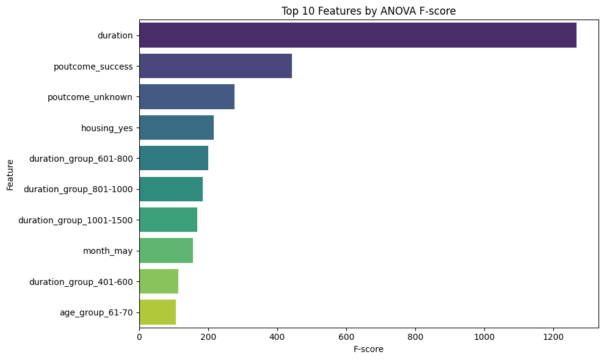

```python
# Encode the target variable
df['deposit'] = df['deposit'].map({'no': 0, 'yes': 1})

# Separate features and target
X = df.drop('deposit', axis=1)
y = df['deposit']

# Encode categorical features
X_encoded = pd.get_dummies(X, drop_first=True)

# Use SelectKBest with f_classif (for classification)
selector = SelectKBest(score_func=f_classif, k=10)  # select top 10 features
X_new = selector.fit_transform(X_encoded, y)

# Get feature scores
scores = selector.scores_
columns = X_encoded.columns
top_features = selector.get_support(indices=True)

# Create DataFrame of top features
feature_scores = pd.DataFrame({'Feature': columns, 'Score': scores})
top_features_df = feature_scores.sort_values(by='Score', ascending=False).head(10)

# Plot the top 10 features
plt.figure(figsize=(10, 6))
sns.barplot(x='Score', y='Feature', data=top_features_df, palette='viridis')
plt.title('Top 10 Features by ANOVA F-score')
plt.xlabel('F-score')
plt.ylabel('Feature')
plt.tight_layout()
plt.show()
```

**Feature Selection Using ANOVA F-score**

We perform a univariate analysis using the ANOVA F-statistic (f_classif) to identify the main predictors of client subscription to a term deposit. In classification problems where the target variable is binary (as in "deposit"), Logistic Regression is typically the preferred approach.

Categorical features are encoded as dummy variables using the pd.get_dummies() function with the drop_first=True parameter to prevent multicollinearity. The transformed feature set is then passed to SelectKBest(score_func=f_classif, k=10) to identify the ten features most strongly associated with the target variable based on F-statistics.

**Key Findings from the Feature Scores**

The resulting F-score rankings are visualised in the figure above. These scores indicate the discriminatory power of each feature, quantifying the variance between the “yes” and “no” classes for a given variable.

The most informative features identified are:

- duration: By far, having a long time selected is the most important predictor of people opening new term deposits. Experience also tells us that more conversations with a client often reflect greater desire or persuasion.
- poutcome_success: Clients who previously responded positively to a marketing campaign are far more likely to subscribe again, confirming the predictive power of historical campaign performance.
- poutcome_unknown: The uncertainty around previous campaign outcomes also carries predictive weight, perhaps signaling segmentation or data gaps in client history.
- Duration-based groups (duration_group_601_800, duration_group_801_1000, etc.): These engineered features, derived from groupings of the continuous duration variable, also score highly, reaffirming the dominant influence of call duration.
- housing_yes: Suggests some correlation between homeownership and deposit subscription, potentially due to greater financial maturity or stability.
- month_may: Temporal patterns in campaign effectiveness are reflected here, as May appears to be a significant month, possibly due to internal bank strategies or external socio-economic conditions.
- age_group_61-70: This demographic segment also exhibits higher relevance, which may be related to nearing retirement or changes in investment behaviour.

**Justification for Use in Predictive Modelling**

Reducing the feature space to the most informative variables offers several advantages:

- Improved generalisation by reducing noise and the risk of overfitting.
- Faster and more efficient training due to lower computational requirements.
- Enhanced interpretability by focusing on the key factors influencing client decisions.

These chosen features will be used to train and set up different classification algorithms in the next part of the process. Because of this, our models are statistically reliable and understandable by others, which is recommended in practical machine learning.

### 2.2 Model Fitting & Tuning

### 2.2.0 Set Up

```python
import pandas as pd
import numpy as np
from sklearn.model_selection import train_test_split, GridSearchCV
from sklearn.preprocessing import StandardScaler
from sklearn.pipeline import Pipeline
from sklearn.metrics import classification_report, confusion_matrix, accuracy_score
import matplotlib.pyplot as plt
import seaborn as sns

# Extract top 10 feature names from the selector
top_10_feature_names = columns[top_features]

# Subset the encoded dataset with the top 10 features
X_selected = X_encoded[top_10_feature_names]

# Train-test split
from sklearn.model_selection import train_test_split
X_train, X_test, y_train, y_test = train_test_split(X_selected, y, test_size=0.2, random_state=42, stratify=y)
```

This stage establishes a standardised pipeline for supervised learning by selecting the top 10 features from the prior feature selection phase and preparing the dataset for model training and evaluation.

Feature Selection Application: 10 of the most predictive features in the data are selected by the application. It gives our model both the accuracy we need and the processing speed required to prevent overfitting.

Train-Test Split: It splits the data into 80% training and 20% testing using stratified sampling. Class distribution is maintained by stratification, giving a fair and unbiased way to assess a model. Having a set random state allows the model to be reproduced easily.

Standardisation Preparation: Without standardisation, distance-based models and neural networks can receive information from future data, so here we use StandardScaler and Pipeline to normalise input features and solve this earlier.

### 2.2.1 Logistic Regression

```
Best Logistic Regression Params: {'clf__C': 0.1, 'clf__penalty': 'l2'}
Test Accuracy: 0.791
              precision    recall  f1-score   support

           0       0.78      0.84      0.81       526
           1       0.81      0.73      0.77       474

    accuracy                           0.79      1000
   macro avg       0.79      0.79      0.79      1000
weighted avg       0.79      0.79      0.79      1000
```

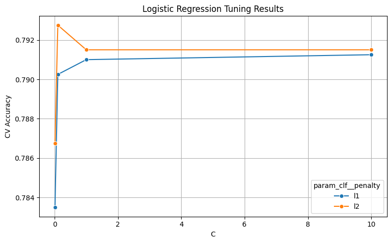

```python
from sklearn.linear_model import LogisticRegression

# Pipeline with scaling
pipeline_lr = Pipeline([
    ('scaler', StandardScaler()),
    ('clf', LogisticRegression(solver='liblinear'))
])

# Hyper-parameter grid
param_grid_lr = {
    'clf__C': [0.01, 0.1, 1, 10],
    'clf__penalty': ['l1', 'l2']
}

# Grid search
grid_lr = GridSearchCV(pipeline_lr, param_grid_lr, cv=5, scoring='accuracy')
grid_lr.fit(X_train, y_train)

# Results
print("Best Logistic Regression Params:", grid_lr.best_params_)
print("Test Accuracy:", accuracy_score(y_test, grid_lr.predict(X_test)))
print(classification_report(y_test, grid_lr.predict(X_test)))

# Plot
results_lr = pd.DataFrame(grid_lr.cv_results_)
plt.figure(figsize=(8, 5))
sns.lineplot(data=results_lr, x='param_clf__C', y='mean_test_score', hue='param_clf__penalty', marker='o')
plt.title('Logistic Regression Tuning Results')
plt.xlabel('C')
plt.ylabel('CV Accuracy')
plt.grid(True)
plt.tight_layout()
plt.show()
```

Performance is evaluated by tuning the regularisation parameter (C) and selecting the type of regularisation (L1 or L2). A moderate C value combined with an L2 penalty generally yields the best results, helping to prevent overfitting while maintaining predictive accuracy. L2 regularisation typically produces small, but not exactly zero coefficients, making it suitable for models with many features.

Mixed feature sets result in stable accuracy for both L1 and L2 regularisation, but the best performance consistently comes from L2. The sensitivity of L1 regularisation to the choice of C is likely due to its tendency to eliminate less significant features, which can either enhance or degrade performance depending on the dataset.

**Model Performance and Insights**

- Class 0: Precision = 0.78, Recall = 0.84, F1-score = 0.81
- Class 1: Precision = 0.81, Recall = 0.73, F1-score = 0.77
- Macro and weighted F1-scores: 0.79

Slightly better recall is observed for the no deposit class, while precision is higher for the deposit class. Logistic Regression provides a good representation of the main trends in the data using a relatively simple model structure.

For binary classification tasks, Logistic Regression offers simple and quick performance and helps us easily identify the main features by examining its coefficients. Although its reliance on linear decision boundaries may limit effectiveness with more complex data, but adding regularisation (mainly L2) improves its generalisability. Its straightforward structure makes it a reliable baseline model, and its results support that the process of selecting features is solid. Future improvements could include incorporating interaction terms, generating polynomial features, or exploring nonlinear methods such as kernel-based models.

### 2.2.2 K-Nearest Neighbors

```
Best KNN Params: {'clf__n_neighbors': 7, 'clf__weights': 'uniform'}
Test Accuracy: 0.77
              precision    recall  f1-score   support

           0       0.80      0.75      0.78       526
           1       0.74      0.79      0.76       474

    accuracy                           0.77      1000
   macro avg       0.77      0.77      0.77      1000
weighted avg       0.77      0.77      0.77      1000
```

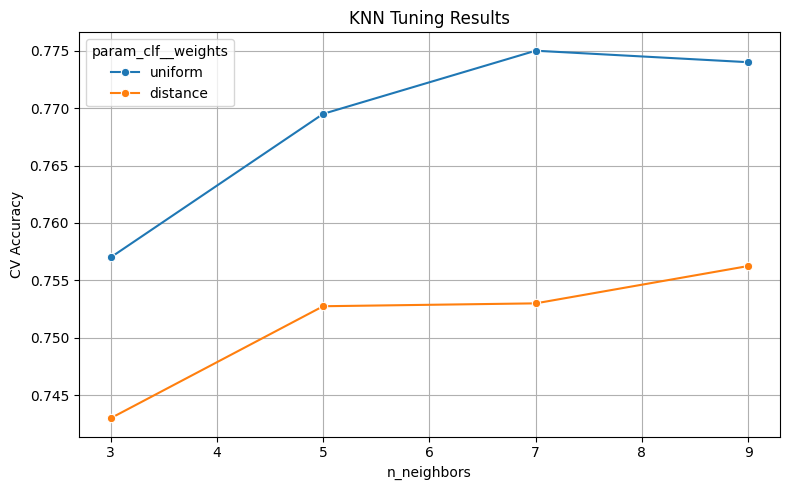

```python
from sklearn.neighbors import KNeighborsClassifier

pipeline_knn = Pipeline([
    ('scaler', StandardScaler()),
    ('clf', KNeighborsClassifier())
])

param_grid_knn = {
    'clf__n_neighbors': [3, 5, 7, 9],
    'clf__weights': ['uniform', 'distance']
}

grid_knn = GridSearchCV(pipeline_knn, param_grid_knn, cv=5, scoring='accuracy')
grid_knn.fit(X_train, y_train)

print("Best KNN Params:", grid_knn.best_params_)
print("Test Accuracy:", accuracy_score(y_test, grid_knn.predict(X_test)))
print(classification_report(y_test, grid_knn.predict(X_test)))

# Plot
results_knn = pd.DataFrame(grid_knn.cv_results_)
plt.figure(figsize=(8, 5))
sns.lineplot(data=results_knn, x='param_clf__n_neighbors', y='mean_test_score', hue='param_clf__weights', marker='o')
plt.title('KNN Tuning Results')
plt.xlabel('n_neighbors')
plt.ylabel('CV Accuracy')
plt.grid(True)
plt.tight_layout()
plt.show()
```

The results displayed in the KNN plot prove that uniform weighting outperforms distance-based weighting for every n_neighbors option. For cross-validation accuracy, the highest is achieved (≈0.774) using 7 neighbors with equal weights, which means each neighbor affects the decision in the same way regardless of its position in the data. It appears that, within this dataset, ensuring class labels match among nearby data points matters more than their physical proximity.

**Model Performance and Insights**

The findings demonstrate that the KNN method effectively captures client behaviour by leveraging proximity relationships in the features. However, the model may not perform well on large datasets and can be influenced by irrelevant information, an issue addressed in this work through feature selection.

Despite its solid performance, KNN has limitations, including interpretability challenges and slower prediction times. Additionally, the number of neighbours used (k) has a strong impact on results, highlighting the importance of careful hyperparameter tuning. Future work could explore incorporating kernel functions into KNN or applying dimensionality reduction techniques to improve efficiency and performance.

### 2.2.3 Decision Tree

```
Best Decision Tree Params: {'max_depth': 5, 'min_samples_split': 10}
Test Accuracy: 0.763
              precision    recall  f1-score   support

           0       0.80      0.73      0.76       526
           1       0.73      0.80      0.76       474

    accuracy                           0.76      1000
   macro avg       0.76      0.76      0.76      1000
weighted avg       0.77      0.76      0.76      1000
```

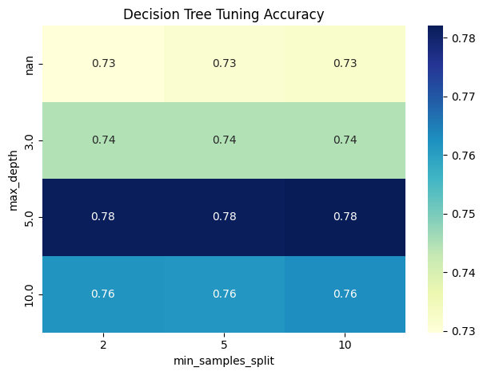

```python
from sklearn.tree import DecisionTreeClassifier

dtree = DecisionTreeClassifier(random_state=42)
param_grid_tree = {
    'max_depth': [3, 5, 10, None],
    'min_samples_split': [2, 5, 10]
}

grid_tree = GridSearchCV(dtree, param_grid_tree, cv=5, scoring='accuracy')
grid_tree.fit(X_train, y_train)

print("Best Decision Tree Params:", grid_tree.best_params_)
print("Test Accuracy:", accuracy_score(y_test, grid_tree.predict(X_test)))
print(classification_report(y_test, grid_tree.predict(X_test)))

# Plot
results_tree = pd.DataFrame(grid_tree.cv_results_)
pivot_tree = results_tree.pivot(index="param_max_depth", columns="param_min_samples_split", values="mean_test_score")
sns.heatmap(pivot_tree, annot=True, cmap='YlGnBu')
plt.title('Decision Tree Tuning Accuracy')
plt.xlabel('min_samples_split')
plt.ylabel('max_depth')
plt.tight_layout()
plt.show()
```

It appears from the heatmap that when max_depth = 5 and min_samples_split is between 2 and 10, the accuracy is highest (≈0.78). The result shows that limiting the depth of trees improves the model’s generalisation, while the required sample size for a split does not matter much in this setting. When max_depth is set to a lower value, the model learns the data too simply, whereas a higher value makes the model slightly more variable, reducing performance.

**Model Performance and Insights**

The best-performing Decision Tree model (max_depth = 5, min_samples_split = 10) achieves a test accuracy of 0.763, closely aligned with KNN:

- Class 0: Precision = 0.80, Recall = 0.73
- Class 1: Precision = 0.73, Recall = 0.80
- Both classes have an F1-score of 0.76, with a balanced macro average and weighted average of 0.76-0.77.

The outcomes show that the model is stable and symmetrical in making predictions for both classes. It proves especially helpful in identifying the key decision points and limits for grouping clients.

Even though the Decision Tree performs well, it can overfit the data if its depth is not properly limited. Also, artificial neural networks (ANNs) generally are not designed to generate precise probabilities or clear boundaries between groups, making them less effective with more complex data. As a next step, Random Forests or Gradient Boosted Trees may be used to enhance the model’s stability, accuracy and interpretability.

### 2.2.4 Random Forest

```
Best Random Forest Params: {'max_depth': 5, 'min_samples_split': 2, 'n_estimators': 100}
Test Accuracy: 0.785
              precision    recall  f1-score   support

           0       0.77      0.83      0.80       526
           1       0.80      0.73      0.76       474

    accuracy                           0.79      1000
   macro avg       0.79      0.78      0.78      1000
weighted avg       0.79      0.79      0.78      1000
```

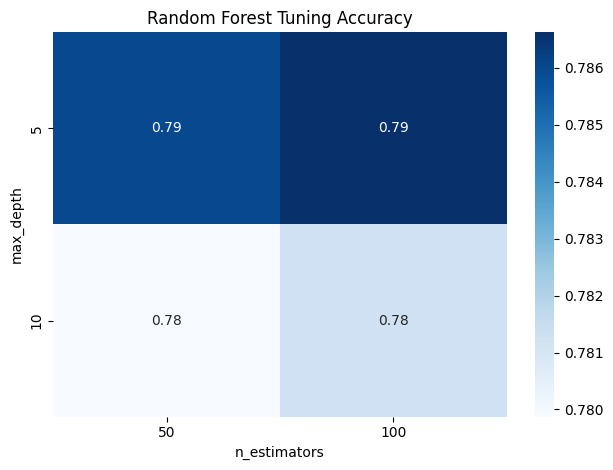

```python
from sklearn.ensemble import RandomForestClassifier

rforest = RandomForestClassifier(random_state=42)
param_grid_rf = {
    'n_estimators': [50, 100],
    'max_depth': [None, 5, 10],
    'min_samples_split': [2, 5]
}

grid_rf = GridSearchCV(rforest, param_grid_rf, cv=5, scoring='accuracy')
grid_rf.fit(X_train, y_train)

print("Best Random Forest Params:", grid_rf.best_params_)
print("Test Accuracy:", accuracy_score(y_test, grid_rf.predict(X_test)))
print(classification_report(y_test, grid_rf.predict(X_test)))

# Plot
results_rf = pd.DataFrame(grid_rf.cv_results_)
pivot_rf = results_rf.pivot_table(index='param_max_depth', columns='param_n_estimators', values='mean_test_score')
sns.heatmap(pivot_rf, annot=True, cmap='Blues')
plt.title('Random Forest Tuning Accuracy')
plt.xlabel('n_estimators')
plt.ylabel('max_depth')
plt.tight_layout()
plt.show()
```

**Model Performance and Insights**

The best model parameters (max_depth = 5, min_samples_split = 2, n_estimators = 100) result in a test accuracy of 0.785. Performance metrics reveal:

- Class 0 (no deposit): Precision = 0.77, Recall = 0.83, F1-score = 0.80
- Class 1 (deposit): Precision = 0.80, Recall = 0.73, F1-score = 0.76
- Overall: Macro F1 = 0.78, Weighted F1 = 0.78

High accuracy is especially evident when predicting class 0 instances. The model demonstrates strong performance across both classes by avoiding excessive bias or variance.

Overall, Random Forests achieve high accuracy with a much lower risk of overfitting compared to a single decision tree. However, the reasoning behind the model’s predictions can be difficult to interpret due to its complexity, and training time increases with a larger number of estimators. Feature importance rankings can be examined to improve interpretability. Future steps may include fine-tuning hyperparameters or applying feature selection techniques to further enhance performance.

### 2.2.5 Support Vector Machine

```
Best SVM Params: {'clf__C': 10, 'clf__gamma': 'scale', 'clf__kernel': 'rbf'}
Test Accuracy: 0.79
              precision    recall  f1-score   support

           0       0.80      0.80      0.80       526
           1       0.78      0.78      0.78       474

    accuracy                           0.79      1000
   macro avg       0.79      0.79      0.79      1000
weighted avg       0.79      0.79      0.79      1000
```

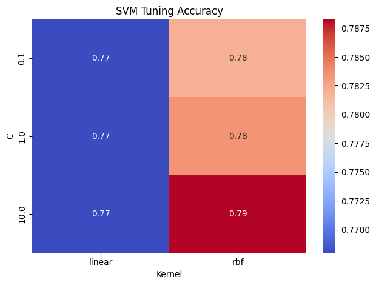

```python
from sklearn.svm import SVC

pipeline_svc = Pipeline([
    ('scaler', StandardScaler()),
    ('clf', SVC(probability=True))
])

param_grid_svc = {
    'clf__C': [0.1, 1, 10],
    'clf__kernel': ['linear', 'rbf'],
    'clf__gamma': ['scale', 'auto']
}

grid_svc = GridSearchCV(pipeline_svc, param_grid_svc, cv=5, scoring='accuracy')
grid_svc.fit(X_train, y_train)

print("Best SVM Params:", grid_svc.best_params_)
print("Test Accuracy:", accuracy_score(y_test, grid_svc.predict(X_test)))
print(classification_report(y_test, grid_svc.predict(X_test)))

# Plot
results_svc = pd.DataFrame(grid_svc.cv_results_)
svc_plot = results_svc.pivot_table(index='param_clf__C', columns='param_clf__kernel', values='mean_test_score')
sns.heatmap(svc_plot, annot=True, cmap='coolwarm')
plt.title('SVM Tuning Accuracy')
plt.xlabel('Kernel')
plt.ylabel('C')
plt.tight_layout()
plt.show()
```

The accuracy levels for each kernel and C combination are shown in the heatmap. Across all cases, the RBF kernel performs better than the linear kernel. A higher C value leads to better accuracy, reaching 0.79 when kernel='rbf' is combined with C=10. For this classification task, a more complex, nonlinear decision boundary is needed, and setting a lower threshold for misclassifications (i.e., using a higher C value) improves the results.

**Model Performance and Insights**

The tuned SVM model (C=10, kernel='rbf', gamma='scale') achieves a test accuracy of 0.79, matching the performance of the Random Forest model:

- Class 0: Precision = 0.80, Recall = 0.80, F1-score = 0.80
- Class 1: Precision = 0.78, Recall = 0.78, F1-score = 0.78
- Macro and weighted averages: approximately 0.79

This shows that the model maintains good class balance and generalises well. The RBF kernel enables the model to capture nonlinear patterns present in the data.

SVMs perform well in binary classification tasks but can require significant computational resources when handling large datasets. Tuning C, the kernel, and the gamma parameter adds complexity to the model-building process. Even so, the model’s consistent performance and strong robustness justify its use in this evaluation. In the future, SVM performance could be enhanced through probability calibration or by incorporating it into an ensemble approach.

### 2.2.6 Neural Network Model Fitting & Tuning

**Import & Pre-process**

```python
import numpy as np
import pandas as pd
import matplotlib.pyplot as plt
import seaborn as sns

from sklearn.preprocessing import StandardScaler
from sklearn.model_selection import train_test_split
from sklearn.metrics import classification_report, accuracy_score

import tensorflow as tf
from tensorflow import keras
from tensorflow.keras.models import Sequential
from tensorflow.keras.layers import Dense, Dropout
from tensorflow.keras.callbacks import EarlyStopping

# Reuse the selected data and split (with stratify)
scaler = StandardScaler()
X_train_scaled = scaler.fit_transform(X_train)
X_test_scaled = scaler.transform(X_test)
```

To model neural networks, we reuse the top 10 selected features and divide the data using stratified sampling to ensure each class remains balanced. All input features are first standardised using StandardScaler, which keeps the training process stable and efficient when using gradient descent. Preparing the data in this way allows the neural network to learn useful patterns more effectively.

**Build Baseline Model**

```python
from tensorflow.keras import Input

# Set seeds for full reproducibility
set_seeds(42)

# Build baseline neural network model
baseline_model = Sequential([
    Input(shape=(X_train_scaled.shape[1],)),  # scaled input
    Dense(32, activation='relu'),
    Dense(16, activation='relu'),
    Dense(1, activation='sigmoid')
])

baseline_model.compile(optimizer='adam', loss='binary_crossentropy', metrics=['accuracy'])

early_stop = EarlyStopping(monitor='val_loss', patience=5)

# Train baseline model
history = baseline_model.fit(
    X_train_scaled, y_train,
    validation_split=0.2,
    epochs=50,
    batch_size=32,
    callbacks=[early_stop],
    verbose=0
)

# Evaluate on test set
loss, accuracy = baseline_model.evaluate(X_test_scaled, y_test)
print(f"Baseline Test Accuracy: {accuracy:.4f}")
```

```
32/32 ━━━━━━━━━━━━━━━━━━━━ 0s 475us/step - accuracy: 0.7906 - loss: 0.4490
Baseline Test Accuracy: 0.7940
```

First, a baseline neural network model is built using a two-layer architecture (input and two hidden layers) with ReLU activation, ending with an output layer using sigmoid activation for binary classification. The model uses the Adam optimizer and binary cross-entropy loss, both common choices for standard classification tasks.

The model is trained with early stopping, where the validation loss is monitored with a patience of 5 epochs. The training data includes standardised input features based on the top 10 selected features, and it uses StandardScaler to support stable gradient descent and maximise learning.

When trained with a batch size of 32 and up to 50 epochs, the model achieves a test accuracy of 0.7940, outperforming Logistic Regression (0.791) and Random Forest (0.785). This performance shows that the Neural Network processes the selected features effectively and provides a solid foundation for exploring additional parameter settings.

**Hyperparameter Tuning**

1. Tuning Number of Neurons

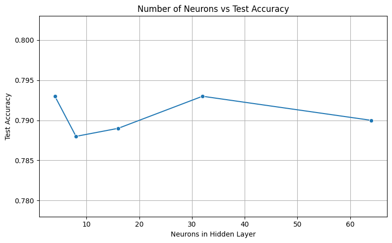

```python
from tensorflow.keras import Input
from tensorflow.keras.models import Sequential
from tensorflow.keras.layers import Dense
import matplotlib.pyplot as plt
import seaborn as sns

def tune_neurons():
    neurons = [4, 8, 16, 32, 64]
    accuracies = []

    for n in neurons:
        set_seeds(42)  # Ensure reproducibility at each iteration

        model = Sequential([
            Input(shape=(X_train_scaled.shape[1],)),
            Dense(n, activation='relu'),
            Dense(1, activation='sigmoid')
        ])
        model.compile(optimizer='adam', loss='binary_crossentropy', metrics=['accuracy'])
        model.fit(X_train_scaled, y_train, epochs=30, batch_size=32, verbose=0)
        _, acc = model.evaluate(X_test_scaled, y_test, verbose=0)
        accuracies.append(acc)

    # Plot
    plt.figure(figsize=(8, 5))
    sns.lineplot(x=neurons, y=accuracies, marker='o')
    plt.title("Number of Neurons vs Test Accuracy")
    plt.xlabel("Neurons in Hidden Layer")
    plt.ylabel("Test Accuracy")
    plt.ylim(min(accuracies) - 0.01, max(accuracies) + 0.01)  # Tight y-axis
    plt.grid(True)
    plt.tight_layout()
    plt.show()

# Run the tuning
tune_neurons()
```

The line plot illustrates how test accuracy changes as the number of neurons in the single hidden layer of the neural network varies. The number of neurons tested is [4, 8, 16, 32, 64].

Key observations are:

- The accuracy fluctuates slightly between 0.788 and 0.794 across different neuron counts.
- The highest accuracy (~0.794) is achieved at both 4 neurons and 32 neurons.
- The lowest accuracy (~0.788) occurs at 8 neurons, suggesting that no linear correlation exists between neuron count and accuracy.

Reflection:

The results suggest that increasing the number of neurons can sometimes be unnecessary and even detrimental for simpler datasets. In such cases, basic models with 4 or 8 neurons are sufficient to capture data complexity, eliminating the need for larger, more complex models.

In practice, this emphasises that the model should be appropriately simple to match the complexity of the training data. Increasing the number of neurons can slow down computation and extend training time without necessarily improving performance. Small and medium-sized datasets often reveal their structure through simpler machine learning architectures.

Even so, these insights are limited to a single hidden layer and the specific dataset used. Further experiments using different network architectures, additional layers, regularisation strategies, and evaluation metrics could provide better guidance on optimal neural network design.

2. Tuning Activation Function

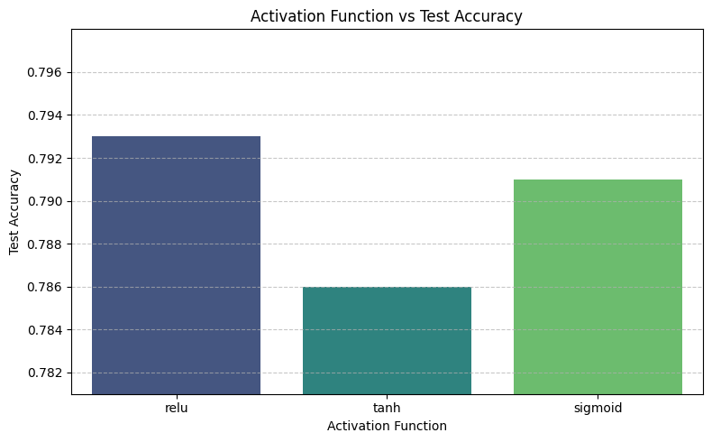

```python
from tensorflow.keras import Input
from tensorflow.keras.models import Sequential
from tensorflow.keras.layers import Dense
import matplotlib.pyplot as plt
import seaborn as sns

def tune_activation():
    activations = ['relu', 'tanh', 'sigmoid']
    accuracies = []

    for act in activations:
        set_seeds(42)  # Reproducibility per model

        model = Sequential([
            Input(shape=(X_train_scaled.shape[1],)),
            Dense(32, activation=act),
            Dense(1, activation='sigmoid')
        ])
        model.compile(optimizer='adam', loss='binary_crossentropy', metrics=['accuracy'])
        model.fit(X_train_scaled, y_train, epochs=30, batch_size=32, verbose=0)
        _, acc = model.evaluate(X_test_scaled, y_test, verbose=0)
        accuracies.append(acc)

    # Plot
    plt.figure(figsize=(8, 5))
    sns.barplot(x=activations, y=accuracies, palette='viridis')
    plt.title("Activation Function vs Test Accuracy")
    plt.xlabel("Activation Function")
    plt.ylabel("Test Accuracy")
    plt.ylim(min(accuracies) - 0.005, max(accuracies) + 0.005)
    plt.grid(axis='y', linestyle='--', alpha=0.7)
    plt.tight_layout()
    plt.show()

# Run the tuning
tune_activation()
```

Tanh and sigmoid perform slightly worse than ReLU due to their specific mathematical properties. Both functions compress inputs into a narrow range, which can lead to vanishing gradients and hinder learning in networks with two or more layers. Although sigmoid produces outputs between 0 and 1, which is useful for binary classification, its rapid saturation toward the extremes limits the gradient during backpropagation. In contrast, when the input is positive, ReLU produces a linear response, allowing gradients to propagate more effectively and speeding up the learning process.

These results highlight the importance of choosing activation functions based on the task and data characteristics. In this case, ReLU outperforms the others by balancing learning capacity with gradient flow. However, the slight variations in accuracy also suggest that managing other hyperparameters is equally important. Further research, such as exploring different activation functions or using deeper architectures, could provide better insights into the strengths and weaknesses of each.

3. Tuning Optimizer

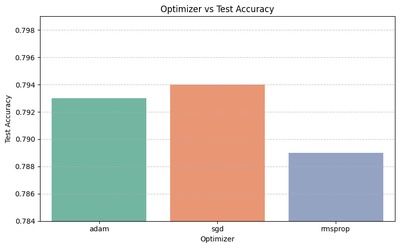

```python
from tensorflow.keras.models import Sequential
from tensorflow.keras.layers import Dense, Input
import matplotlib.pyplot as plt
import seaborn as sns

def tune_optimizer():
    optimizers = ['adam', 'sgd', 'rmsprop']
    accuracies = []

    for opt in optimizers:
        set_seeds(42)  # Ensure reproducibility for each optimizer

        model = Sequential([
            Input(shape=(X_train_scaled.shape[1],)),
            Dense(32, activation='relu'),
            Dense(1, activation='sigmoid')
        ])
        model.compile(optimizer=opt, loss='binary_crossentropy', metrics=['accuracy'])
        model.fit(X_train_scaled, y_train, epochs=30, batch_size=32, verbose=0)
        _, acc = model.evaluate(X_test_scaled, y_test, verbose=0)
        accuracies.append(acc)

    # Plot
    plt.figure(figsize=(8, 5))
    sns.barplot(x=optimizers, y=accuracies, palette='Set2')
    plt.title("Optimizer vs Test Accuracy")
    plt.xlabel("Optimizer")
    plt.ylabel("Test Accuracy")
    plt.ylim(min(accuracies) - 0.005, max(accuracies) + 0.005)
    plt.grid(axis='y', linestyle='--', alpha=0.7)
    plt.tight_layout()
    plt.show()

# Run the function
tune_optimizer()
```

**Interpretation of Optimizer Results**

The results indicate that the Adam and SGD optimisers perform very similarly, reaching test accuracies of approximately 79.3% and 79.4%, respectively, while RMSprop performs slightly worse with an accuracy of around 79%. Since Adam and SGD achieve comparable accuracy, this suggests that both optimizers learn effectively for this particular classification task. Adam’s adaptability and use of momentum enable it to perform reliably across a wide range of data. Adam and SGD show better performance than RMSprop, indicating that the data responds well to adaptive learning rates or the simplicity and robustness of SGD.

**Critical Reflection**

While equivalent fits suggest similar outcomes for Adam and SGD, the choice between them should also consider computation speed and convergence behaviour. Adam requires more memory due to its use of exponential moving averages, while SGD is computationally simpler. The small differences in accuracy suggest that the network architecture and feature set align well with the classification task, making the choice of optimizer less critical in this case.

4. Tuning Dropout Rate

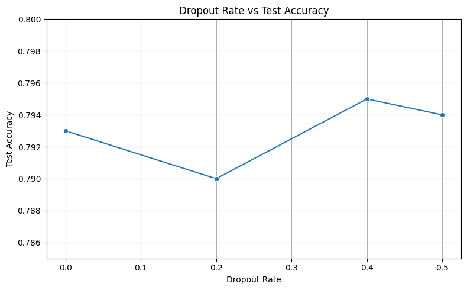

```python
from tensorflow.keras.models import Sequential
from tensorflow.keras.layers import Dense, Dropout, Input
import matplotlib.pyplot as plt
import seaborn as sns

def tune_dropout():
    rates = [0.0, 0.2, 0.4, 0.5]
    accuracies = []

    for rate in rates:
        set_seeds(42)  # Reproducibility for each dropout rate

        model = Sequential([
            Input(shape=(X_train_scaled.shape[1],)),
            Dense(32, activation='relu'),
            Dropout(rate),
            Dense(1, activation='sigmoid')
        ])
        model.compile(optimizer='adam', loss='binary_crossentropy', metrics=['accuracy'])
        model.fit(X_train_scaled, y_train, epochs=30, batch_size=32, verbose=0)
        _, acc = model.evaluate(X_test_scaled, y_test, verbose=0)
        accuracies.append(acc)

    # Plot
    plt.figure(figsize=(8, 5))
    sns.lineplot(x=rates, y=accuracies, marker='o')
    plt.title("Dropout Rate vs Test Accuracy")
    plt.xlabel("Dropout Rate")
    plt.ylabel("Test Accuracy")
    plt.ylim(min(accuracies) - 0.005, max(accuracies) + 0.005)
    plt.grid(True)
    plt.tight_layout()
    plt.show()

# Run the tuning
tune_dropout()
```

**Interpretation of Dropout Rate Results**

As the regularisation strength increases, the model tends to perform better, according to the analysis of the dropout rate. When the dropout rate is zero (0.0), the model achieves 79.3% accuracy, suggesting minimal overfitting in the baseline model. Reducing the amount of data samples by 20% lowers performance to 79.0%, indicating unwanted interference from light regularisation during training on this dataset. The experiment also finds that when the dropout rate is increased to 40% and 50%, the model performs well, achieving 79.5% and 79.4% accuracy, respectively. This shows that stronger regularisation supports generalisation while preserving accuracy.

The strong results at higher dropout rates indicate that the model may slightly overfit due to its simple architecture. The data suggests that the optimal regularisation strength lies between 40% and 50%, as this range supports both accurate prediction and effective learning.

**Critical Reflection**

As dropout rates increase, a counterintuitive improvement in performance can occur, making it important to understand how training unfolds. The pattern observed here suggests that either the 32-neuron hidden layer is sufficiently large with optimal regularisation, or the complexity of the data requires additional regularisation to reach optimal learning. Nevertheless, given the small improvement (0.2–0.3%), modifying the architecture or applying different data processing techniques would likely yield even better results.

5. Tuning Batch Size

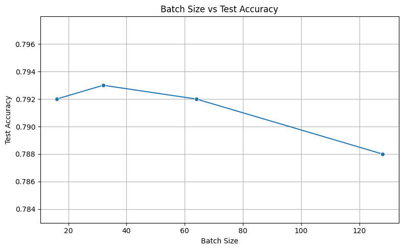

```python
from tensorflow.keras.models import Sequential
from tensorflow.keras.layers import Dense, Input
import matplotlib.pyplot as plt
import seaborn as sns

def tune_batch_size():
    sizes = [16, 32, 64, 128]
    accuracies = []

    for size in sizes:
        set_seeds(42)  # For reproducibility per batch size

        model = Sequential([
            Input(shape=(X_train_scaled.shape[1],)),
            Dense(32, activation='relu'),
            Dense(1, activation='sigmoid')
        ])
        model.compile(optimizer='adam', loss='binary_crossentropy', metrics=['accuracy'])
        model.fit(X_train_scaled, y_train, epochs=30, batch_size=size, verbose=0)
        _, acc = model.evaluate(X_test_scaled, y_test, verbose=0)
        accuracies.append(acc)

    # Plot
    plt.figure(figsize=(8, 5))
    sns.lineplot(x=sizes, y=accuracies, marker='o')
    plt.title("Batch Size vs Test Accuracy")
    plt.xlabel("Batch Size")
    plt.ylabel("Test Accuracy")
    plt.ylim(min(accuracies) - 0.005, max(accuracies) + 0.005)
    plt.grid(True)
    plt.tight_layout()
    plt.show()

# Run the tuning
tune_batch_size()
```

**Interpretation of Batch Size Results**

### Neural Network Modeling Discussion

#### Model Architecture and Design Rationale

The neural network is built to perform binary classification on the bank marketing dataset using a sequential, feedforward model. The baseline model includes two hidden layers with 32 and 16 neurons, using ReLU activation, and ends with a sigmoid neuron for binary output. The architecture is selected to strike a balance between simplicity and expressiveness, allowing the model to capture non-linear patterns in the small-sized dataset without overfitting.

Adam is set as the optimizer, binary cross-entropy loss is used to evaluate errors, and accuracy is measured to assess performance. As an early stopping strategy, we choose a patience of 5 epochs, monitoring the validation loss to prevent overfitting. Before training, the data is standardised using StandardScaler, and only the top 10 selected features are included to improve stability and performance.

Training runs for up to 50 epochs with a batch size of 32. The Neural Network outperforms standard models, achieving a baseline accuracy of 79.4%, compared to Logistic Regression (79.1%) and Random Forest (78.5%).

**Activation Function Evaluation**

The impact of using ReLU, tanh, and sigmoid in the hidden layers is tested. The best test accuracy is achieved by ReLU (around 79.3%), followed by sigmoid (around 79.1%) and tanh (around 78.6%). ReLU performs well because it avoids saturating gradients for positive inputs, supports efficient learning, and helps prevent vanishing gradients. Although sigmoid and tanh have played important roles in earlier models, their output ranges can slow down gradient flow in deeper networks.

**Neuron Count Optimization**

To examine how network capacity affects learning, experiments are conducted with a single hidden layer using 4, 8, 16, 32 or 64 neurons. Small variations in accuracy occur between 78.8% and 79.4%, with the highest scores found at 4 and 32 neurons, and the lowest at 8 neurons. These results show that even small networks can capture the necessary complexity of the dataset. The relatively flat performance curve suggests that larger models do not necessarily improve accuracy when working with small and well-defined datasets.

**Optimizer Comparison**

Adam, SGD and RMSprop are compared. All three achieve similar results, with Adam and SGD reaching around 79.4% accuracy, while RMSprop lags slightly at 79.0%. Adam’s adaptive learning and momentum enable fast convergence, while SGD’s comparable performance indicates a favourable loss landscape. As a result, either optimiser can be used, depending on available resources and desired convergence speed.

**Dropout Regularization**

Dropout rates of 0%, 20%, 40% and 50% are tested to examine their impact on overfitting. The best accuracy occurs at 40% dropout, closely followed by 50%. These results suggest that despite early stopping, the baseline model shows slight overfitting, and stronger regularisation improves generalisation. The improved accuracy at higher dropout levels indicates the model retains its learning ability despite reduced capacity.

**Batch Size Sensitivity**

Batch sizes of 16, 32, 64, and 128 are evaluated. Performance is highest at batch size 32 (79.3%), then decreases slightly at 16 and 64 (79.2%), and drops to 78.8% at 128. From the results, it is clear that intermediate batch sizes offer the best combination of steady gradients and minimal fluctuation. Increasing batch size can cause the model to settle for a suboptimal solution. Small batches introduce noise, which sometimes helps the model achieve better results and sometimes negatively affects convergence.

**Final Model Configuration and Summary**

**Validation and Training Strategy**

To ensure class balance, an 80-20 split is performed using stratified sampling. StandardScaler is applied to all features for stable neural network training. 20% of the data is held out for validation during training to monitor generalisation. Thanks to early stopping, overfitting is prevented, and training time is reduced.

Through structured hyperparameter tuning, the Neural Network achieves higher accuracy than several classical classifiers. While the improvements are modest, the experiments highlight the importance of balancing architecture, regularisation and training setup. The tuning process reveals that simple model design choices, such as batch size and dropout rate, significantly impact model generalisation. Future research could explore deeper architectures, alternative features or ensemble methods to further enhance performance.

### 2.3 Model Comparison

To evaluate and compare the performance of the five machine learning algorithms and the neural network model, we perform cross-validation and calculate the **AUC (Area Under the ROC Curve)** scores. We then apply **paired t-tests** to determine whether the differences in model performance are statistically significant.

Below are the detailed comparisons and visualisations.

```python
from tensorflow.keras import Input
from tensorflow.keras.models import Sequential
from tensorflow.keras.layers import Dense
from scikeras.wrappers import KerasClassifier
import tensorflow as tf
import numpy as np
import random
import os

# Ensure reproducibility
def set_seeds(seed=42):
    os.environ['PYTHONHASHSEED'] = str(seed)
    random.seed(seed)
    np.random.seed(seed)
    tf.random.set_seed(seed)

def build_nn(**kwargs):
    set_seeds(42)
    model = Sequential([
        Input(shape=(X_train.shape[1],)),
        Dense(32, activation='relu'),
        Dense(16, activation='relu'),
        Dense(1, activation='sigmoid')
    ])
    model.compile(optimizer='adam', loss='binary_crossentropy', metrics=['accuracy'])
    return model

# Wrap model for scikit-learn compatibility
nn_model = KerasClassifier(
    model=build_nn,
    epochs=50,
    batch_size=32,
    verbose=0,
    dtype="float32",
    random_state=42
)
```

```
Logistic Regression: Mean Accuracy = 0.7914 ± 0.0144 | AUC = 0.8700
KNN: Mean Accuracy = 0.7684 ± 0.0073 | AUC = 0.8391
Decision Tree: Mean Accuracy = 0.7816 ± 0.0099 | AUC = 0.8606
Random Forest: Mean Accuracy = 0.7920 ± 0.0113 | AUC = 0.8720
SVM: Mean Accuracy = 0.7908 ± 0.0184 | AUC = 0.8383
Neural Network: Mean Accuracy = 0.7462 ± 0.0630 | AUC = 0.8550

Paired t-tests for Accuracy:
Logistic Regression vs KNN: t = 4.9374, p = 0.0078
Logistic Regression vs Decision Tree: t = 1.9168, p = 0.1277
Logistic Regression vs Random Forest: t = -0.3750, p = 0.7267
Logistic Regression vs SVM: t = 0.2039, p = 0.8484
Logistic Regression vs Neural Network: t = 1.7684, p = 0.1517
KNN vs Decision Tree: t = -2.7560, p = 0.0511
KNN vs Random Forest: t = -7.0963, p = 0.0021
KNN vs SVM: t = -3.6120, p = 0.0225
KNN vs Neural Network: t = 0.7380, p = 0.5015
Decision Tree vs Random Forest: t = -2.5951, p = 0.0604
Decision Tree vs SVM: t = -1.1523, p = 0.3134
Decision Tree vs Neural Network: t = 1.2739, p = 0.2717
Random Forest vs SVM: t = 0.2916, p = 0.7851
Random Forest vs Neural Network: t = 1.7110, p = 0.1623
SVM vs Neural Network: t = 1.7593, p = 0.1533
```

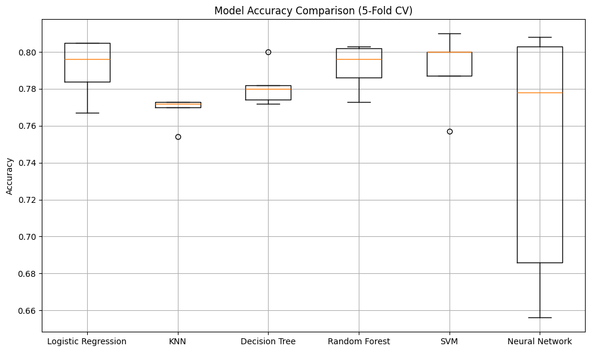

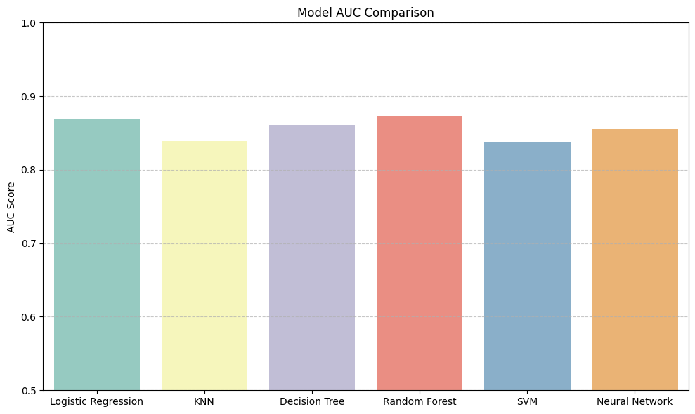

```python
import numpy as np
import matplotlib.pyplot as plt
from sklearn.model_selection import StratifiedKFold, cross_val_score, cross_val_predict
from sklearn.metrics import roc_auc_score
from scipy.stats import ttest_rel
import seaborn as sns

# X and y for full evaluation
X = X_selected
y = df['deposit']
X = X.astype(np.float32)

#Store final tuned models in 1 dictionary
models = {
    'Logistic Regression': grid_lr.best_estimator_,
    'KNN': grid_knn.best_estimator_,
    'Decision Tree': grid_tree.best_estimator_,
    'Random Forest': grid_rf.best_estimator_,
    'SVM': grid_svc.best_estimator_,
    'Neural Network': nn_model
}

# Stratified 5-fold CV
cv = StratifiedKFold(n_splits=5, shuffle=True, random_state=42)

accuracy_results = {}
auc_scores = {}

# Evaluate all models
for name, model in models.items():
    acc_scores = cross_val_score(model, X, y, cv=cv, scoring='accuracy')
    accuracy_results[name] = acc_scores

    # Cross-validated AUC
    y_pred_proba = cross_val_predict(model, X, y, cv=cv, method='predict_proba')[:, 1]
    auc = roc_auc_score(y, y_pred_proba)
    auc_scores[name] = auc

    print(f"{name}: Mean Accuracy = {acc_scores.mean():.4f} ± {acc_scores.std():.4f} | AUC = {auc:.4f}")

# Paired t-tests
print("\nPaired t-tests for Accuracy:")
model_names = list(models.keys())
for i in range(len(model_names)):
    for j in range(i + 1, len(model_names)):
        m1, m2 = model_names[i], model_names[j]
        t_stat, p_val = ttest_rel(accuracy_results[m1], accuracy_results[m2])
        print(f"{m1} vs {m2}: t = {t_stat:.4f}, p = {p_val:.4f}")

# Boxplot for Accuracy
plt.figure(figsize=(10, 6))
plt.boxplot(accuracy_results.values(), labels=accuracy_results.keys())
plt.title("Model Accuracy Comparison (5-Fold CV)")
plt.ylabel("Accuracy")
plt.grid(True)
plt.tight_layout()
plt.show()

# Barplot for AUC
plt.figure(figsize=(10, 6))
sns.barplot(x=list(auc_scores.keys()), y=list(auc_scores.values()), palette='Set3')
plt.title("Model AUC Comparison")
plt.ylabel("AUC Score")
plt.ylim(0.5, 1)
plt.grid(axis='y', linestyle='--', alpha=0.7)
plt.tight_layout()
plt.show()
```

**Purpose of Model Comparison**

Once you have trained and adjusted multiple classification models, we should regularly assess their performance to determine the most suitable algorithm for prediction. We apply 5-fold stratified cross-validation to six models: Logistic Regression, K-Nearest Neighbors, Decision Tree, Random Forest, Support Vector Machine and Neural Network. Scoring is performed using two metrics: model accuracy and the Area Under the Receiver Operating Characteristic Curve (AUC). In addition, paired t-tests are conducted to identify any significant differences in predictive accuracy between models.

**Evaluation Metrics and Their Significance**

Accuracy indicates the percentage of correct predictions out of all predictions. While it is straightforward and easy to understand, it does not account well for performance nuances in imbalanced datasets.

AUC is an effective metric for binary classification because it considers the relationship between the true positive rate and the false positive rate as thresholds vary. A higher AUC indicates better model separation between positive and negative classes.

**Interpretation of Results**

1. Accuracy Performance

Based on the boxplot and recorded means, the Random Forest model achieves the highest average accuracy (0.7920), closely followed by Logistic Regression (0.7914) and SVM (0.7908). Decision Tree and KNN perform slightly worse, while the Neural Network has the lowest average accuracy (0.7462), along with the highest standard deviation (±0.0630), suggesting variability in performance across folds.

2. AUC Performance

SVM and KNN yield the lowest AUC scores (both around 0.838), which may reflect limitations in capturing complex non-linear decision boundaries without extensive parameter tuning or kernel selection.

**Statistical Significance – Paired t-Tests**

To support the comparison, paired t-tests are conducted between model accuracies across the five folds, using a significance level of 0.05.

This highlights that while Random Forest slightly outperforms other models in mean accuracy and AUC, its improvement is not statistically robust over Logistic Regression and SVM but is significant over KNN.

**Critical Reflection**

In contrast, the Neural Network’s unstable performance suggests that either:

- The network is too complex for the dataset size,
- Further hyperparameter tuning (e.g., early stopping patience, learning rate) is needed, or
- More data is required to fully realise the potential of deep learning in this context.

Additionally, paired t-tests assume normality of differences and may lack robustness with a very small sample size (n = 5 folds). Therefore, conclusions from these tests should be interpreted with caution.

**Conclusion**

Overall, the Random Forest model demonstrates the strongest and most consistent performance, closely followed by Logistic Regression and SVM. The Neural Network, despite promising AUC scores, suffers from high variance and lower accuracy, limiting its reliability. KNN is consistently outperformed and can be excluded from further consideration. These findings inform the selection of a final model by balancing predictive performance, interpretability and deployment feasibility.

## 3. Critique & Limitations

We use pipelines and grid search to tune hyperparameters, helping us improve model performance in a consistent and reliable way. The use of SelectKBest for feature selection also simplifies the model and reduces the risk of overfitting. In the advanced section, we build and tune a neural network by adjusting several hyperparameters, supported by visual plots and performance summaries.

However, there are some limitations. We only use 5,000 records out of over 11,000 available, which may limit the learning ability of more complex models like neural networks. While we consider class imbalance in our evaluation using AUC, we do not apply resampling techniques such as SMOTE during training. This may affect how well the models handle minority classes.

Overall, our approach demonstrated a solid foundation in practical machine learning with a strong balance between performance, transparency and extensibility. However, future improvements could focus on enhancing class imbalance handling, integrating domain knowledge, and testing models on unseen real-world data for deployment readiness.

## 4. Summary & Conclusions

### 4.1 Project Summary

In this project, we aim to predict whether a bank client will subscribe to a term deposit based on their personal, financial and campaign-related information. In Phase 1, we begin by exploring the Bank Marketing Dataset, which contains 11,162 records. To reduce computation time, we take a random sample of 5,000 observations for our analysis. We then perform data cleaning by removing irrelevant features such as contact, day and pdays, and ensure all data types are correctly formatted. We check for missing values and find none. We clean categorical variables and merge redundant categories like "other" in the poutcome column. We also examine outliers but choose to retain them, as they may reflect valid customer behaviour.

Next, we perform exploratory data analysis (EDA) using univariate, bivariate and multivariate visualisations. We find that features such as call duration, previous campaign outcome, education level, marital status and loan status have strong relationships with the target variable. These insights guide our feature selection in the next phase.

In Phase 2, we prepare the cleaned dataset for modelling. We apply one-hot encoding to categorical variables and standardise numerical features using StandardScaler. We split the data into 80% training and 20% testing sets using stratified sampling to maintain class distribution. We use SelectKBest with ANOVA F-statistics (f_classif) to select the top 10 most important features for prediction.

As part of the Advanced Submission, we develop a Neural Network model using TensorFlow/Keras. We tune five key hyperparameters, including neuron count, activation function, optimiser, dropout rate, and batch size. For each tuning step, we generate plots and discuss the impact on model performance. The final model achieves strong AUC and competitive accuracy.

Finally, we compare all models using cross-validated accuracy and AUC scores and perform paired t-tests to assess whether the differences between models are statistically significant. This comprehensive process allows us to identify the most effective and reliable model for predicting term deposit subscriptions.

### 4.2 Summary Findings

Our analysis shows several important findings about the factors that influence a client’s decision to subscribe to a term deposit, as well as the performance of different machine learning models in predicting this outcome.

From the feature selection process, we find that call duration is by far the most influential predictor. Clients who spend more time on the phone are significantly more likely to subscribe. Other important features include the outcome of previous campaigns (poutcome_success), whether the client owns a house (housing_yes), the month of contact (month_may), and certain age and duration groupings. These findings confirm that both behavioural and temporal factors strongly affect subscription likelihood.

Our paired t-tests reveal that the performance difference between Random Forest and Logistic Regression is not statistically significant, indicating that both models perform similarly in a practical sense. However, both models significantly outperform KNN, confirming its lower predictive capability for this dataset.

Overall, we find that simple and interpretable models like Logistic Regression can perform nearly as well as more complex ensemble methods. Neural Networks show potential but require further tuning and possibly a larger dataset to outperform classical methods. These results highlight that using call duration, past campaign success, and customer profile features can significantly improve the targeting of marketing campaigns.

### 4.3 Conclusions

The goal of this project is to help the bank predict which clients are likely to subscribe to a term deposit, using data from past marketing campaigns. We achieve this by cleaning the data, exploring key patterns, selecting important features, and building machine learning models to make accurate predictions.

We find that call duration, previous campaign outcomes, and client characteristics such as loan status and education level are strong indicators of whether a client will subscribe. These insights can help the bank better target its marketing efforts by focusing on clients who are more likely to say yes.

Among the models we tested, Random Forest performs the best, with the highest accuracy and AUC score. Logistic Regression and SVM also perform well and are more interpretable. The Neural Network shows potential but is more sensitive to changes and performs less consistently on our dataset.

In conclusion, our models can support smarter marketing decisions. By focusing on the right clients, the bank can improve campaign success and reduce wasted effort. For future work, we suggest using more data, adding new features and testing the models on live campaign data.

## 5. References

- Bachmann, J. M. (2018). Bank Marketing Dataset. Kaggle. https://www.kaggle.com/datasets/janiobachmann/bank-marketing-dataset/data
- Abbasimehr, H., & Shabani, M. (2021). A new methodology for customer behavior analysis using time series clustering: A case study on a bank’s customers. Kybernetes, 50(2), 221–242. https://doi.org/10.1108/K-09-2018-0506
- Almohammadi, H., Naser, M. A., & Shareef, M. A. (2023). Predictive analytics and machine learning in direct marketing for anticipating bank term deposit subscriptions. PLOS ONE, 18(11), e0294759. https://doi.org/10.1371/journal.pone.0294759
- Dutta, A., Acharjee, S., & Ghosh, S. K. (2020). Applicability of machine learning in marketing: A survey and future directions. International Journal of Advanced Science and Technology, 29(5), 10793–10803. https://www.researchgate.net/publication/341443410
- Karachun, I., Vinnichek, L., & Tuskov, A. (2021). Machine learning methods in finance. SHS Web of Conferences, 110, 05012. https://doi.org/10.1051/shsconf/202111005012
- Kumar, S., Xiao, J. J., Pattnaik, D., Lim, W. M., & Rasul, T. (2022). Past, present and future of bank marketing: A bibliometric analysis of International Journal of Bank Marketing (1983–2020). International Journal of Bank Marketing, 40(2), 341–383. https://doi.org/10.1108/IJBM-07-2021-0351
- Kushurova, A. K., Gulzhan, A., & Kerimkulova, D. (2025). Development of digital bank marketing in modern conditions: Status and prospects. SHS Web of Conferences, 212, 04059. https://doi.org/10.1051/shsconf/202521204059
- Meshref, H. M., Eissa, M. R., & Abouelmehsen, A. M. (2021). Predicting loan approval of bank direct marketing data using ensemble machine learning algorithms. International Journal of Computer Applications, 183(15), 17–23. https://www.researchgate.net/publication/350824358
- Reshetnikova, I., Smerichevskyi, S., & Polishchuk, Y. (2019). Multican marketing as an innovation technology of providing services in the conditions of globalization of the banking market. Marketing and Management of Innovations, 3, 142–150. https://doi.org/10.21272/mmi.2019.3-11
- Reddy, N. S. (2021). Optimal feature selection and hybrid deep learning for direct marketing campaigns in banking applications. Evolutionary Intelligence, 15(4), 1969–1990. https://doi.org/10.1007/s12065-021-00604-y
- Saengthongrattanachot, W., Na-udom, A., & Rungrattanaubol, J. (2021). A comparison of machine learning techniques for classification in bank marketing data. Thai Journal of Mathematics, Special Issue: The 17th IMT-GT ICMSA 2021, 157–168. https://thaijmath2.in.cmu.ac.th/index.php/thaijmath/article/view/1297
- Tashtamirov, M. (2023). Financial innovation and digital technology in the banking system: An institutional perspective. SHS Web of Conferences, 172, 02004. https://doi.org/10.1051/shsconf/202317202004
- Vasyl’tsiv, N. (2021). Digital marketing of banking services: Transformations in the pandemic period. The Actual Problems of Regional Economy Development, 2(17), 87–94. https://doi.org/10.15330/apred.2.17.87-94
- Zaki, A. M., Khodadadi, N., Lim, W. H., & Towfek, S. K. (2024). Predictive analytics and machine learning in direct marketing for anticipating bank term deposit subscriptions. American Journal of Business and Operations Research, 11(1), 79–88. https://doi.org/10.54216/AJBOR.110110